# Heart Disease Prediction Using Logistic Regression and Decision Tree Classification

Bei Wang, PhD student in epidemiology at dpt of PHS

02/26/2022

# Task

My task is a **binary classification** of heart disease using the Heart Disease Dataset from the UCI repositories among about 900 individuals. The **target** was coded as a binary varible indicating the presence of heart disease. **13 features** in the demographic and biomarker aspects are available for predicting heart disease.

Data source: https://archive.ics.uci.edu/ml/datasets/heart+disease

Link to the recording to my presentation: https://drive.google.com/file/d/1vlpYFx6In8ZPlY46ua_8V6XjlV-dneZR/view?usp=sharing

## 1. Data exploration

```python
%matplotlib inline
import pandas as pd
import numpy as np
from numpy import nan
from collections import Counter
from sklearn.preprocessing import OneHotEncoder
import seaborn as sns
import matplotlib.pyplot as plt
import warnings
warnings.filterwarnings('ignore')
```

```python
#read in data collected from 4 different sites
col_names= ["age", "sex", "cp", "trestbps", "chol",
      "fbs", "restecg", "thalach", "exang", "oldpeak",
       "slope", "ca", "thal", "num"]
cleveland = pd.read_csv("processed.cleveland.data", sep=",", names=col_names)
hunga = pd.read_csv("processed.hungarian.data", sep=",", names=col_names)
swiss = pd.read_csv("processed.switzerland.data", sep=",", names=col_names)
va = pd.read_csv("processed.va.data", sep=",", names=col_names)
```

```python
#combine rows
frames=[cleveland, hunga, swiss, va]
heart= pd.concat(frames, keys=['cleveland', 'hunga', 'swiss', 'va'])
```

### The data has 920 rows of observations and 14 columns that represent the 14 features

```python
#data size and features
heart.shape
```

```
(920, 14)
```

```python
heart
```

|  |  | age | sex | cp | trestbps | chol | fbs | restecg | thalach | exang | oldpeak | slope | ca | thal | num |
| --- | --- | --- | --- | --- | --- | --- | --- | --- | --- | --- | --- | --- | --- | --- | --- |
| cleveland | 0 | 63.0 | 1.0 | 1.0 | 145.0 | 233.0 | 1.0 | 2.0 | 150.0 | 0.0 | 2.3 | 3.0 | 0.0 | 6.0 | 0 |
|  | 1 | 67.0 | 1.0 | 4.0 | 160.0 | 286.0 | 0.0 | 2.0 | 108.0 | 1.0 | 1.5 | 2.0 | 3.0 | 3.0 | 2 |
|  | 2 | 67.0 | 1.0 | 4.0 | 120.0 | 229.0 | 0.0 | 2.0 | 129.0 | 1.0 | 2.6 | 2.0 | 2.0 | 7.0 | 1 |
|  | 3 | 37.0 | 1.0 | 3.0 | 130.0 | 250.0 | 0.0 | 0.0 | 187.0 | 0.0 | 3.5 | 3.0 | 0.0 | 3.0 | 0 |
|  | 4 | 41.0 | 0.0 | 2.0 | 130.0 | 204.0 | 0.0 | 2.0 | 172.0 | 0.0 | 1.4 | 1.0 | 0.0 | 3.0 | 0 |
| ... | ... | ... | ... | ... | ... | ... | ... | ... | ... | ... | ... | ... | ... | ... | ... |
| va | 195 | 54.0 | 0.0 | 4.0 | 127 | 333 | 1 | 1 | 154 | 0 | 0 | ? | ? | ? | 1 |
|  | 196 | 62.0 | 1.0 | 1.0 | ? | 139 | 0 | 1 | ? | ? | ? | ? | ? | ? | 0 |
|  | 197 | 55.0 | 1.0 | 4.0 | 122 | 223 | 1 | 1 | 100 | 0 | 0 | ? | ? | 6 | 2 |
|  | 198 | 58.0 | 1.0 | 4.0 | ? | 385 | 1 | 2 | ? | ? | ? | ? | ? | ? | 0 |
|  | 199 | 62.0 | 1.0 | 2.0 | 120 | 254 | 0 | 2 | 93 | 1 | 0 | ? | ? | ? | 1 |

920 rows × 14 columns

### Target variable

Orginal target variable is a multi-class variable with 0 indicating no heart disease and 1,2,3,4 indicating presence of heart disease.

```python
# distribution of the target varible (0 is absence of heart disease)
heart['num'].value_counts()
```

```
0    411
1    265
2    109
3    107
4     28
Name: num, dtype: int64
```

Recode into a binary target variable. This looks pretty balanced.

```python
#create a binary target varible of heart disease based on 'num'
heart['target'] = np.where((heart.num == 0), 0, 1)
heart['target'].value_counts()
```

```
1    509
0    411
Name: target, dtype: int64
```

Visualize class distribution of target

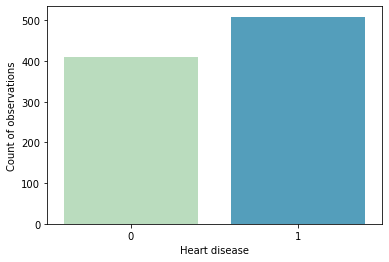

```python
dx = sns.countplot(x='target', data = heart, palette = "GnBu")
dx.set_ylabel("Count of observations")
dx.set_xlabel("Heart disease")

plt.show()
```

## 2. Data Preprocessing

### 2.1 Missing values

There are two main sources of missingness in this data. By looking at the data frame, I can see that there are values marked as "?". According to the docomentation, negative -9.0 was used to represent missing values.

```python
heart.info()
```

```
<class 'pandas.core.frame.DataFrame'>
MultiIndex: 920 entries, ('cleveland', 0) to ('va', 199)
Data columns (total 15 columns):
 #   Column    Non-Null Count  Dtype
---  ------    --------------  -----
 0   age       920 non-null    float64
 1   sex       920 non-null    float64
 2   cp        920 non-null    float64
 3   trestbps  920 non-null    object
 4   chol      920 non-null    object
 5   fbs       920 non-null    object
 6   restecg   920 non-null    object
 7   thalach   920 non-null    object
 8   exang     920 non-null    object
 9   oldpeak   920 non-null    object
 10  slope     920 non-null    object
 11  ca        920 non-null    object
 12  thal      920 non-null    object
 13  num       920 non-null    int64
 14  target    920 non-null    int64
dtypes: float64(3), int64(2), object(10)
memory usage: 121.2+ KB
```

Count missing values marked as "?" in the data and replace them with nan.

```python
qm= (heart[heart.columns] == "?").sum()
qm
```

```
age           0
sex           0
cp            0
trestbps     59
chol         30
fbs          90
restecg       2
thalach      55
exang        55
oldpeak      62
slope       309
ca          611
thal        486
num           0
target        0
dtype: int64
```

```python
# mark them with nan
heart[heart.columns[:]]= heart[heart.columns[:]].replace("?", nan)
```

```python
# turn non-numeric columns to numeric
heart[heart.columns[:]]= heart[heart.columns[:]].apply(pd.to_numeric)
```

```python
# examine -9.0
neg_9= (heart[heart.columns] == -9.0).sum()
neg_9
```

```
age         0
sex         0
cp          0
trestbps    0
chol        0
fbs         0
restecg     0
thalach     0
exang       0
oldpeak     0
slope       0
ca          0
thal        0
num         0
target      0
dtype: int64
```

```python
# final missing values counting
print("Missing values", heart.isnull().sum())
```

```
Missing values age           0
sex           0
cp            0
trestbps     59
chol         30
fbs          90
restecg       2
thalach      55
exang        55
oldpeak      62
slope       309
ca          611
thal        486
num           0
target        0
dtype: int64
```

### 2.2 Imputation and feature selection

Based on the missing value table above, I will drop 'slope', 'ca', and 'thal' because more than 30% of the data are missing in these variables. Also, drop 'num' as it's replaced by the target variable created. I end up with **10 predictors** to use now.

```python
drop= ['slope', 'ca', 'thal','num']
heart= heart[heart.columns.drop(drop)]
```

For the rest of the features, I will impute with the most frequent values of each feature.

```python
from sklearn.impute import SimpleImputer
imputer=SimpleImputer(strategy='most_frequent')
heart = pd.DataFrame(imputer.fit_transform(heart), columns=heart.columns)
```

```python
# missing values are imputed now
print("Missing values ", heart.isnull().sum())
```

```
Missing values  age         0
sex         0
cp          0
trestbps    0
chol        0
fbs         0
restecg     0
thalach     0
exang       0
oldpeak     0
target      0
dtype: int64
```

Examine highly correlated predictors

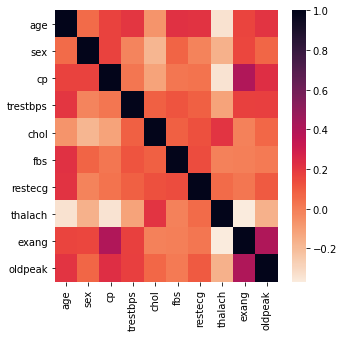

```python
predictors= heart[heart.columns.drop('target')]
ax=plt.subplots(figsize=(5,5))
corr= predictors.corr()
sns.heatmap(corr, cmap=sns.cm.rocket_r)
```

Rank correlated pair by absolute values

```python
def rank_corr_pair (df, n):
    corr= df.corr().abs().unstack()
    corr= corr.sort_values(ascending=False)
    return corr[0: n]
```

```python
rank_corr_pair(predictors, 20)
```

```
age       age         1.000000
sex       sex         1.000000
exang     exang       1.000000
thalach   thalach     1.000000
restecg   restecg     1.000000
fbs       fbs         1.000000
chol      chol        1.000000
trestbps  trestbps    1.000000
cp        cp          1.000000
oldpeak   oldpeak     1.000000
          exang       0.408454
exang     oldpeak     0.408454
          cp          0.401888
cp        exang       0.401888
exang     thalach     0.369813
thalach   exang       0.369813
cp        thalach     0.338009
thalach   cp          0.338009
          age         0.332598
age       thalach     0.332598
dtype: float64
```

No pairs look like highly correlated in the 0.7-0.9 range.

### 2.3 Examine and one-hot code categorical features

There are **5 out of 10 features(predictors) that should be treated as categrical** as listed below. I create **2 versions of dummy variables**. For logistic regression, I need to drop a category of each categorical feature as a reference category, so that the coefficients correctly represents the log odds ratio of the other categories compared to the reference category. Another version of dummy varibles does not drop categories as such.

- sex: 1(male); 0(female)
- cp(chest pain type): 1(typical angina); 2(atypical angina); 3(non-anginal pain); 4(asymptomatic)
- restecg(resting electrocardiographic): 0(normal); 1(having ST-T wave abnormality); 2(showing probable or definite left ventricular hypertrophy by Estes' criteria)
- fbs(fasting blood sugar > 120 mg/dl): 1(true); 0(false)
- exang(exercise induced angina): 1(yes); 0(no)

```python
heart.nunique()
```

```
age          50
sex           2
cp            4
trestbps     61
chol        217
fbs           2
restecg       3
thalach     119
exang         2
oldpeak      53
target        2
dtype: int64
```

```python
# create dummy variables for the categorical features, the first level of each categorical feature was dropped
cat_vars= heart[['sex', 'cp', 'restecg', 'fbs', 'exang']]
# drop a category of the dummy varibles for logistic regression
ohe= OneHotEncoder(drop= "first")
ohe.fit(cat_vars)
cat_ohe= ohe.transform(cat_vars).toarray()
cat_ohe= pd.DataFrame(cat_ohe, columns= ohe.get_feature_names(cat_vars.columns), index= heart.index)

# do not drop for decision tree classification
ohe1= OneHotEncoder()
ohe1.fit(cat_vars)
cat_ohe1= ohe1.transform(cat_vars).toarray()
cat_ohe1= pd.DataFrame(cat_ohe1, columns= ohe1.get_feature_names(cat_vars.columns), index= heart.index)
```

The fewer feature version will be used for logistic regression while the largers one used for decision tree classification

```python
cat_ohe.shape, cat_ohe1.shape
```

```
((920, 8), (920, 13))
```

```python
cat_ohe
```

|  | sex_1.0 | cp_2.0 | cp_3.0 | cp_4.0 | restecg_1.0 | restecg_2.0 | fbs_1.0 | exang_1.0 |
| --- | --- | --- | --- | --- | --- | --- | --- | --- |
| 0 | 1.0 | 0.0 | 0.0 | 0.0 | 0.0 | 1.0 | 1.0 | 0.0 |
| 1 | 1.0 | 0.0 | 0.0 | 1.0 | 0.0 | 1.0 | 0.0 | 1.0 |
| 2 | 1.0 | 0.0 | 0.0 | 1.0 | 0.0 | 1.0 | 0.0 | 1.0 |
| 3 | 1.0 | 0.0 | 1.0 | 0.0 | 0.0 | 0.0 | 0.0 | 0.0 |
| 4 | 0.0 | 1.0 | 0.0 | 0.0 | 0.0 | 1.0 | 0.0 | 0.0 |
| ... | ... | ... | ... | ... | ... | ... | ... | ... |
| 915 | 0.0 | 0.0 | 0.0 | 1.0 | 1.0 | 0.0 | 1.0 | 0.0 |
| 916 | 1.0 | 0.0 | 0.0 | 0.0 | 1.0 | 0.0 | 0.0 | 0.0 |
| 917 | 1.0 | 0.0 | 0.0 | 1.0 | 1.0 | 0.0 | 1.0 | 0.0 |
| 918 | 1.0 | 0.0 | 0.0 | 1.0 | 0.0 | 1.0 | 1.0 | 0.0 |
| 919 | 1.0 | 1.0 | 0.0 | 0.0 | 0.0 | 1.0 | 0.0 | 1.0 |

920 rows × 8 columns

```python
# replace the 5 categorical features with the dummy variables
heart_lr = pd.concat([heart, cat_ohe], axis=1)
heart_lr = heart_lr[heart_lr.columns.drop(cat_vars)]
heart_dt = pd.concat([heart, cat_ohe1], axis=1)
heart_dt = heart_dt[heart_dt.columns.drop(cat_vars)]
```

```python
heart_lr.shape, heart_dt.shape
```

```
((920, 14), (920, 19))
```

```python
heart_dt
```

|  | age | trestbps | chol | thalach | oldpeak | target | sex_0.0 | sex_1.0 | cp_1.0 | cp_2.0 | cp_3.0 | cp_4.0 | restecg_0.0 | restecg_1.0 | restecg_2.0 | fbs_0.0 | fbs_1.0 | exang_0.0 | exang_1.0 |
| --- | --- | --- | --- | --- | --- | --- | --- | --- | --- | --- | --- | --- | --- | --- | --- | --- | --- | --- | --- |
| 0 | 63.0 | 145.0 | 233.0 | 150.0 | 2.3 | 0.0 | 0.0 | 1.0 | 1.0 | 0.0 | 0.0 | 0.0 | 0.0 | 0.0 | 1.0 | 0.0 | 1.0 | 1.0 | 0.0 |
| 1 | 67.0 | 160.0 | 286.0 | 108.0 | 1.5 | 1.0 | 0.0 | 1.0 | 0.0 | 0.0 | 0.0 | 1.0 | 0.0 | 0.0 | 1.0 | 1.0 | 0.0 | 0.0 | 1.0 |
| 2 | 67.0 | 120.0 | 229.0 | 129.0 | 2.6 | 1.0 | 0.0 | 1.0 | 0.0 | 0.0 | 0.0 | 1.0 | 0.0 | 0.0 | 1.0 | 1.0 | 0.0 | 0.0 | 1.0 |
| 3 | 37.0 | 130.0 | 250.0 | 187.0 | 3.5 | 0.0 | 0.0 | 1.0 | 0.0 | 0.0 | 1.0 | 0.0 | 1.0 | 0.0 | 0.0 | 1.0 | 0.0 | 1.0 | 0.0 |
| 4 | 41.0 | 130.0 | 204.0 | 172.0 | 1.4 | 0.0 | 1.0 | 0.0 | 0.0 | 1.0 | 0.0 | 0.0 | 0.0 | 0.0 | 1.0 | 1.0 | 0.0 | 1.0 | 0.0 |
| ... | ... | ... | ... | ... | ... | ... | ... | ... | ... | ... | ... | ... | ... | ... | ... | ... | ... | ... | ... |
| 915 | 54.0 | 127.0 | 333.0 | 154.0 | 0.0 | 1.0 | 1.0 | 0.0 | 0.0 | 0.0 | 0.0 | 1.0 | 0.0 | 1.0 | 0.0 | 0.0 | 1.0 | 1.0 | 0.0 |
| 916 | 62.0 | 120.0 | 139.0 | 150.0 | 0.0 | 0.0 | 0.0 | 1.0 | 1.0 | 0.0 | 0.0 | 0.0 | 0.0 | 1.0 | 0.0 | 1.0 | 0.0 | 1.0 | 0.0 |
| 917 | 55.0 | 122.0 | 223.0 | 100.0 | 0.0 | 1.0 | 0.0 | 1.0 | 0.0 | 0.0 | 0.0 | 1.0 | 0.0 | 1.0 | 0.0 | 0.0 | 1.0 | 1.0 | 0.0 |
| 918 | 58.0 | 120.0 | 385.0 | 150.0 | 0.0 | 0.0 | 0.0 | 1.0 | 0.0 | 0.0 | 0.0 | 1.0 | 0.0 | 0.0 | 1.0 | 0.0 | 1.0 | 1.0 | 0.0 |
| 919 | 62.0 | 120.0 | 254.0 | 93.0 | 0.0 | 1.0 | 0.0 | 1.0 | 0.0 | 1.0 | 0.0 | 0.0 | 0.0 | 0.0 | 1.0 | 1.0 | 0.0 | 0.0 | 1.0 |

920 rows × 19 columns

## 3. Model selection and evaluation

- Logistic regression
- Decision tree classification

```python
from sklearn.tree import DecisionTreeClassifier
from sklearn import tree
from dmba import classificationSummary
from sklearn.model_selection import train_test_split
from sklearn.preprocessing import StandardScaler
```

```
no display found. Using non-interactive Agg backend
```

### 3.1 Logistic regression

Use the data (heart_lr) with dummy variables that dropped the first categories.

#### 3.1.1 Split and standardization of numeric predictors

70% training and 30% testing

```python
target= ['target']
X, y = heart_lr[heart_lr.columns.drop(target)], heart_lr[target]
#split
train_X, test_X, train_y, test_y = train_test_split(X, y, test_size=0.3, random_state=42)
#standardize features

print('Training_X: ', train_X.shape)
print('Validation_X: ', test_X.shape)
print('Training_y: ', train_y.shape)
print('Validation_y: ', test_y.shape)
```

```
Training_X:  (644, 13)
Validation_X:  (276, 13)
Training_y:  (644, 1)
Validation_y:  (276, 1)
```

```python
Counter(train_y['target'])
```

```
Counter({0.0: 291, 1.0: 353})
```

```python
Counter(test_y['target'])
```

```
Counter({0.0: 120, 1.0: 156})
```

It looks pretty balanced, no need to stratify.

```python
# standardize the numeric values and leave dummy variables intact
scaler = StandardScaler()

#train_X
num_columns= train_X.columns.drop(cat_ohe.columns)
num_std= pd.DataFrame(scaler.fit_transform(train_X[num_columns]), columns= num_columns, index= train_X.index)
train_X_std= pd.concat([num_std, train_X[cat_ohe.columns]], axis=1)

#test_X
num_columns= test_X.columns.drop(cat_ohe.columns)
num_std= pd.DataFrame(scaler.fit_transform(test_X[num_columns]), columns= num_columns, index= test_X.index)
test_X_std= pd.concat([num_std, test_X[cat_ohe.columns]], axis=1)
```

The dataframe looks okay

```python
train_X_std
```

|  | age | trestbps | chol | thalach | oldpeak | sex_1.0 | cp_2.0 | cp_3.0 | cp_4.0 | restecg_1.0 | restecg_2.0 | fbs_1.0 | exang_1.0 |
| --- | --- | --- | --- | --- | --- | --- | --- | --- | --- | --- | --- | --- | --- |
| 363 | -1.167353 | -0.589528 | 0.097561 | 1.058429 | -0.760478 | 0.0 | 1.0 | 0.0 | 0.0 | 0.0 | 0.0 | 0.0 | 0.0 |
| 481 | 0.570605 | -0.063980 | -0.014819 | -0.553078 | 0.146798 | 0.0 | 1.0 | 0.0 | 0.0 | 0.0 | 0.0 | 0.0 | 0.0 |
| 650 | 0.136115 | -0.589528 | -1.640009 | -1.810840 | -0.488295 | 1.0 | 0.0 | 0.0 | 1.0 | 1.0 | 0.0 | 0.0 | 0.0 |
| 483 | 0.570605 | -0.063980 | 1.108982 | -0.710299 | 0.146798 | 1.0 | 0.0 | 1.0 | 0.0 | 0.0 | 0.0 | 0.0 | 1.0 |
| 355 | -1.275975 | -0.852302 | 0.184007 | -0.042113 | -0.760478 | 0.0 | 0.0 | 1.0 | 0.0 | 1.0 | 0.0 | 0.0 | 0.0 |
| ... | ... | ... | ... | ... | ... | ... | ... | ... | ... | ... | ... | ... | ... |
| 106 | 0.570605 | 0.461568 | -0.109910 | 0.940514 | -0.760478 | 1.0 | 0.0 | 0.0 | 1.0 | 0.0 | 0.0 | 0.0 | 1.0 |
| 270 | 0.787849 | 0.461568 | 0.149428 | -0.002808 | 0.963347 | 1.0 | 0.0 | 0.0 | 1.0 | 0.0 | 1.0 | 0.0 | 1.0 |
| 860 | 2.308562 | 1.512665 | 1.039825 | -1.024739 | 1.054075 | 1.0 | 0.0 | 0.0 | 1.0 | 0.0 | 0.0 | 1.0 | 1.0 |
| 435 | -0.081129 | 0.461568 | 0.227230 | 0.154413 | 1.054075 | 0.0 | 1.0 | 0.0 | 0.0 | 0.0 | 0.0 | 0.0 | 1.0 |
| 102 | 0.353360 | -0.169089 | 0.979312 | 0.822599 | -0.760478 | 0.0 | 0.0 | 0.0 | 1.0 | 0.0 | 1.0 | 0.0 | 0.0 |

644 rows × 13 columns

```python
train_X_std.shape, test_X_std.shape
```

```
((644, 13), (276, 13))
```

#### General models selection steps

- Hyper-parameter tuning: apply GridSearch and a 10-folds cross validation in the training set to select the best model
- Evaluate the best model performance in the test set that was set aside

```python
from sklearn.linear_model import LogisticRegression
from sklearn.model_selection import  GridSearchCV
from sklearn.metrics import classification_report
```

#### 3.1.2 GridSearch and cross-validation

```python
params= {
    'penalty': ['l1','l2', 'none', 'elasticnet'],
    'C': [0.01, 0.1, 1, 10, 100],
    'solver': ['saga']

}
gridsearch= GridSearchCV(LogisticRegression(random_state=42), params, cv=10, n_jobs=-1,scoring= 'accuracy')
gridsearch.fit(train_X_std, train_y)
print('best score:', gridsearch.best_score_)
print('best parameters:', gridsearch.best_params_)
lr_best= gridsearch.best_estimator_
```

```
best score: 0.8076442307692308
best parameters: {'C': 1, 'penalty': 'l2', 'solver': 'saga'}
```

#### 3.1.3 Model performance in the test set

```python
from sklearn.base import clone
lr_best= clone(lr_best)
lr_best.fit(train_X_std, train_y)
lr_best.score(test_X_std, test_y)
```

```
0.7862318840579711
```

```python
target_names= ['no heart disease', 'heart disease']
print(classification_report(test_y, lr_best.predict(test_X_std), target_names= target_names))
```

```
                  precision    recall  f1-score   support

no heart disease       0.76      0.75      0.75       120
   heart disease       0.81      0.81      0.81       156

        accuracy                           0.79       276
       macro avg       0.78      0.78      0.78       276
    weighted avg       0.79      0.79      0.79       276
```

```python
classificationSummary(test_y, lr_best.predict(test_X_std))
```

```
Confusion Matrix (Accuracy 0.7862)

       Prediction
Actual   0   1
     0  90  30
     1  29 127
```

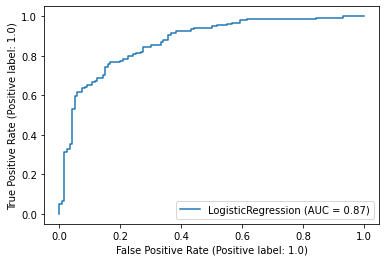

```python
from sklearn.metrics import plot_roc_curve
import matplotlib.pyplot as plt
plot_roc_curve(lr_best, test_X_std, test_y)
plt.show()
```

It appears that the default logistic regression model (C=1, penalty= 'l2') has the best performance after 10-folds cross validation using the training data.

Looking at the coefficients, several factors seems to play significant roles in predicting the probability of having heart disease such as sex, cp, exang, oldpeak, etc.

```python
df_lr = pd.DataFrame({'features': train_X_std.columns, 'coefficients': lr_best.coef_.ravel()})
df_lr= df_lr.sort_values('coefficients', ascending= False)
df_lr
```

|  | features | coefficients |
| --- | --- | --- |
| 5 | sex_1.0 | 1.465795 |
| 8 | cp_4.0 | 1.437297 |
| 12 | exang_1.0 | 0.869750 |
| 4 | oldpeak | 0.623822 |
| 11 | fbs_1.0 | 0.394598 |
| 9 | restecg_1.0 | 0.379616 |
| 0 | age | 0.247329 |
| 10 | restecg_2.0 | 0.063020 |
| 1 | trestbps | 0.042117 |
| 7 | cp_3.0 | -0.085375 |
| 3 | thalach | -0.233088 |
| 2 | chol | -0.401926 |
| 6 | cp_2.0 | -0.672758 |

### 3.2 Decision tree classification

Following similar model selection steps

```python
from sklearn.tree import DecisionTreeClassifier
```

#### 3.2.1 Split the data

No need to standardize

```python
target= ['target']
X, y = heart_dt[heart_dt.columns.drop(target)], heart_dt[target]
#split
train_X, test_X, train_y, test_y = train_test_split(X, y, test_size=0.3, random_state=42)
print('Training_X: ', train_X.shape)
print('Validation_X: ', test_X.shape)
print('Training_y: ', train_y.shape)
print('Validation_y: ', test_y.shape)
```

```
Training_X:  (644, 18)
Validation_X:  (276, 18)
Training_y:  (644, 1)
Validation_y:  (276, 1)
```

#### 3.2.2 Gridsearch and cross-validation

```python
params= {
    'criterion': ['entropy','gini'],
    'max_depth': list(range(1,10)),
    'max_features': list(range(1,10))
}

gridsearch= GridSearchCV(DecisionTreeClassifier(random_state=42), params, cv=10, n_jobs=-1, scoring= 'accuracy')
gridsearch.fit(train_X, train_y)
print('best score:', gridsearch.best_score_)
print('best parameters:', gridsearch.best_params_)
dt_best= gridsearch.best_estimator_
```

```
best score: 0.7935096153846154
best parameters: {'criterion': 'gini', 'max_depth': 3, 'max_features': 5}
```

#### 3.2.3 Model performance in the test set

```python
dt_best= clone(dt_best)
dt_best.fit(train_X, train_y)
```

```
DecisionTreeClassifier(max_depth=3, max_features=5, random_state=42)
```

```python
classificationSummary(test_y, dt_best.predict(test_X))
```

```
Confusion Matrix (Accuracy 0.7826)

       Prediction
Actual   0   1
     0  93  27
     1  33 123
```

```python
target_names= ['no heart disease', 'heart disease']
print(classification_report(test_y, dt_best.predict(test_X), target_names= target_names))
```

```
                  precision    recall  f1-score   support

no heart disease       0.74      0.78      0.76       120
   heart disease       0.82      0.79      0.80       156

        accuracy                           0.78       276
       macro avg       0.78      0.78      0.78       276
    weighted avg       0.78      0.78      0.78       276
```

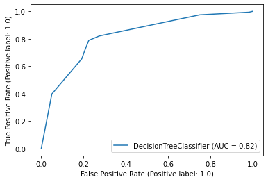

```python
plot_roc_curve(dt_best, test_X, test_y)
plt.show()
```

#### Feature importance

```python
importance= dt_best.feature_importances_
cols= train_X.columns
df_dt= pd.DataFrame({'feature': cols,
                 'importance': importance})
df_dt= df_dt.sort_values('importance', ascending=False)
df_dt
```

|  | feature | importance |
| --- | --- | --- |
| 17 | exang_1.0 | 0.458277 |
| 10 | cp_4.0 | 0.316970 |
| 6 | sex_1.0 | 0.164224 |
| 3 | thalach | 0.060529 |
| 16 | exang_0.0 | 0.000000 |
| 15 | fbs_1.0 | 0.000000 |
| 14 | fbs_0.0 | 0.000000 |
| 13 | restecg_2.0 | 0.000000 |
| 12 | restecg_1.0 | 0.000000 |
| 11 | restecg_0.0 | 0.000000 |
| 0 | age | 0.000000 |
| 1 | trestbps | 0.000000 |
| 8 | cp_2.0 | 0.000000 |
| 7 | cp_1.0 | 0.000000 |
| 5 | sex_0.0 | 0.000000 |
| 4 | oldpeak | 0.000000 |
| 2 | chol | 0.000000 |
| 9 | cp_3.0 | 0.000000 |

### 4. Summary and conclusion

Through hyper-parameter tuning and 10-folds cross validation, the best models selected by logistic regression and decision tree have an AUC score of 0.87 and 0.82, respectively. They both have pretty high performance. The decision tree classifier narrowed down to only 4 features, greatly reducing the complexity and model variance. So the *decision tree classifier is more optimal compared to logistic regression model in this task of heart disease classification*.

#### Logistic regression

From the logistic regression, we can see that several features are more important, such as sex, chest pain type, and exercise induced angina. This is consistent with the decision tree classifier.

```python
def plot_feature_importance(importance, names, model_type):
    feature_importance= np.array(importance)
    feature_names= np.array(names)
    df= pd.DataFrame({
        'Feature names': feature_names,
        'Feature importance': feature_importance
    })
    df= df.sort_values(by= 'Feature importance', ascending=False, key= pd.Series.abs)#sort by absolute values
    #plot
    plt.figure(figsize=(8,8))
    sns.barplot(x=df['Feature importance'], y= df['Feature names'])
    plt.title(model_type + ' feature importance')
    plt.xlabel('Feature importance')
    plt.ylabel('Feature names')
```

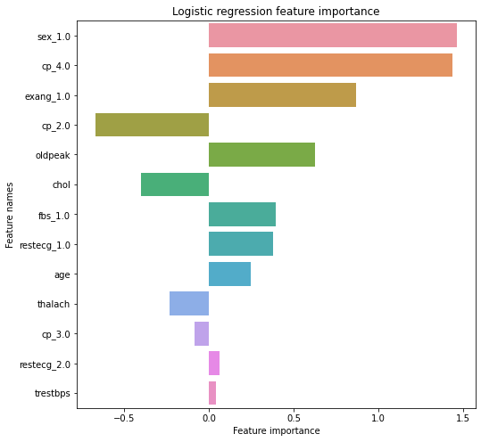

```python
plot_feature_importance(lr_best.coef_.reshape(-1,), lr_best.feature_names_in_, 'Logistic regression' )
```

#### Decision tree

The decision tree classfier retained only 4 features, which are exercise induced angina, asymptomatic angina, male, and maximum heart rate achieved. They seem to be variables that are easy to collect among people who are at risk of heart disease.

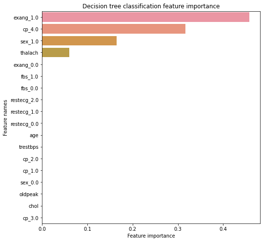

```python
plot_feature_importance(dt_best.feature_importances_, dt_best.feature_names_in_, 'Decision tree classification' )
```

#### Plot the decision tree classifier

```python
import pydotplus
from  sklearn import tree
from IPython.display import Image
```

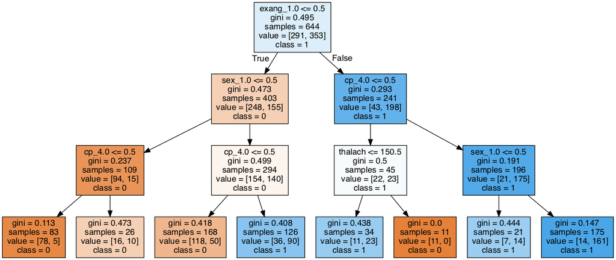

```python
dot_dat= tree.export_graphviz(dt_best, feature_names= dt_best.feature_names_in_, class_names= ['0', '1'],filled=True)

graph= pydotplus.graph_from_dot_data(dot_dat)
Image(graph.create_png())
```